# Exercise 9.3: Predicting Prices of Used Cars (Regression Trees)

Emily Schmidt

2022-11-16

**Completed exercise using the Data Mining textbook, not the errata.**

```r
library(data.table) # Fast aggregation of large data sets and a fast file reader
library(caret) # Functions that attempt to streamline the process for creating predictive models*
library(reshape2) # Easily transform our data into whatever
library(tidyr) # Contains tools for changing the shape and hierarchy of a data set
library(rpart) # Used for building classification and regression trees
library(rpart.plot) # Automatically scales and adjusts the displayed tree for best fit
library(rattle) # Graphical Data Interface
library(RColorBrewer) # Contains a ready-to-use color palettes for creating beautiful graphics
library(scales) # Convert value into a dollar amount
library(Metrics) # RMSE()
library(dplyr) # Select()
library(tidyverse) # Rotate text labels
theme_set(theme_bw(16)) # Rotate text labels
```

```r
setwd("C:\\Users\\emann\\GSEM Master\\Data Mining\\Homework 3") # Set directory
getwd() # Check the working directory
```

```
## [1] "C:/Users/emann/GSEM Master/Data Mining/Homework 3"
```

```r
Toyota <- read.csv("ToyotaCorolla.csv", sep = ",", header = T) # Load your data, ToyotaCorolla
```

**Exploratory Analysis** was completed in Exercise 6.4. Please refer to that HTLM for further information on the ToyotaCorolla dataset.

**A.** *Run a regression tree (RT) with outcome variable Price and predictors Age_08_04, KM, Fuel_Type, HP, Automatic, Doors, Quarterly_Tax, Mfg_Guarantee, Guarantee_Period, Airco, Automatic_Airco, CD_Player, Powered_Windows, Sport_Model, and Tow_Bar. Keep the minimum number of records in a terminal node to 1, maximum number of tree levels to 100, and cp = 0.001, to make the run least restrictive.*

**i.** *. Which appear to be the three or four most important car specifications for predicting the car’s price?*

```r
Toyota$Fuel_Type = as.factor(Toyota$Fuel_Type) # Creates dummy variable

set.seed(1) #  Set the seed for the random number generator for reproducing the partition. (page 258)

# Partitioning into training (60%) and validation (40%) (page 38)
train.index <- sample(rownames(Toyota), 0.6*dim(Toyota)[1])
train.df <- Toyota[train.index, ] # Collect all the columns with training rows into training set (page 38)

valid.index <- setdiff(row.names(Toyota), train.index) # # Assign rows that are not already in the training set into validation (page 38)
valid.df <- Toyota[valid.index, ] # Collect all the columns with validation rows into validation set (page 38)
```

We begin by distributing 60% of our data to the training set while the other 40% goes into validation. Training contains 861 observations while the other set has 575 Toyota Corollas.

```r
# Create regression tree with "anova" and other specified parameters (page 224)
RegressTree <- rpart(formula = Price ~ Age_08_04 + KM + Fuel_Type + HP + Automatic + Doors +
              Quarterly_Tax + Mfr_Guarantee + Guarantee_Period + Airco +
              Automatic_airco + CD_Player + Powered_Windows + Sport_Model + Tow_Bar,
            data = train.df, method = "anova",
            control = rpart.control(minbucket = 1, maxdepth = 30, cp = 0.001))
# Cannot run max 100 as the maximum depth is 30
# Need to use anova since we are fitting a regression tree

RegressTree # Explains the splits
```

```
## n= 861
##
## node), split, n, deviance, yval
##       * denotes terminal node
##
##   1) root 861 11995140000 10812.970
##     2) Age_08_04>=32.5 743  2900685000  9615.801
##       4) Age_08_04>=57.5 471   813509300  8647.943
##         8) Age_08_04>=68.5 226   257064600  7875.686
##          16) KM>=99385.5 72    87644380  7318.056 *
##          17) KM< 99385.5 154   136564300  8136.396
##            34) Airco< 0.5 113    92276630  7941.239 *
##            35) Airco>=0.5 41    28122380  8674.268 *
##         9) Age_08_04< 68.5 245   297333200  9360.310
##          18) HP< 88 97   133055100  8800.629
##            36) KM>=155251.5 4     1228701  6400.250 *
##            37) KM< 155251.5 93   107787900  8903.871
##              74) Doors< 4.5 60    56855540  8609.667 *
##              75) Doors>=4.5 33    36296450  9438.788 *
##          19) HP>=88 148   113979300  9727.128
##            38) Quarterly_Tax< 78.5 52    27586240  9273.750 *
##            39) Quarterly_Tax>=78.5 96    69914600  9972.708 *
##       5) Age_08_04< 57.5 272   881961300 11291.760
##        10) Age_08_04>=43.5 165   495026100 10566.080
##          20) HP< 79 24   104184500  8407.917
##            40) Quarterly_Tax< 124.5 6    26048330  6066.667
##              80) CD_Player< 0.5 4      387500  4675.000 *
##              81) CD_Player>=0.5 2     2420000  8850.000 *
##            41) Quarterly_Tax>=124.5 18    34284600  9188.333
##              82) KM>=174069.5 3      915000  7050.000 *
##              83) KM< 174069.5 15    16908710  9616.000 *
##          21) HP>=79 141   260029900 10933.430
##            42) Quarterly_Tax< 78.5 74   152541900 10519.580
##              84) Automatic_airco< 0.5 72    80287310 10410.400 *
##              85) Automatic_airco>=0.5 2    40500000 14450.000 *
##            43) Quarterly_Tax>=78.5 67    80815360 11390.520
##              86) CD_Player< 0.5 48    26758310 11099.480 *
##              87) CD_Player>=0.5 19    39719410 12125.790
##               174) KM>=118586 2      405000  9450.000 *
##               175) KM< 118586 17    23310040 12440.590 *
```

[output cut: 17 more lines]

```
##             100) KM>=30499 12     8843665 16945.330 *
##             101) KM< 30499 11    15851360 18418.180 *
##            51) Fuel_Type=Diesel 2           0 22250.000 *
##        13) Age_08_04< 16.5 33   142847500 19454.700
##          26) Automatic_airco< 0.5 20    33102010 18318.250
##            52) KM>=18114 6     9202083 17008.330 *
##            53) KM< 18114 14     9192373 18879.640 *
##          27) Automatic_airco>=0.5 13    44176480 21203.080
##            54) Doors< 4.5 5     4432000 19910.000 *
##            55) Doors>=4.5 8    26159090 22011.250 *
##       7) HP>=113 12   205790600 24864.580
##        14) Age_08_04>=5.5 9    23500560 22622.220
##          28) Fuel_Type=Petrol 5     6665000 21550.000 *
##          29) Fuel_Type=Diesel 4     3901875 23962.500 *
##        15) Age_08_04< 5.5 3     1275417 31591.670 *
```

```r
printcp(RegressTree) # Generates a cost complexity parameter table that provides the complexity parameter value
```

```
##
## Regression tree:
## rpart(formula = Price ~ Age_08_04 + KM + Fuel_Type + HP + Automatic +
##     Doors + Quarterly_Tax + Mfr_Guarantee + Guarantee_Period +
##     Airco + Automatic_airco + CD_Player + Powered_Windows + Sport_Model +
##     Tow_Bar, data = train.df, method = "anova", control = rpart.control(minbucket = 1,
##     maxdepth = 30, cp = 0.001))
##
## Variables actually used in tree construction:
##  [1] Age_08_04       Airco           Automatic_airco CD_Player
##  [5] Doors           Fuel_Type       HP              KM
##  [9] Powered_Windows Quarterly_Tax
##
## Root node error: 1.1995e+10/861 = 13931635
##
```

[output cut: 35 more lines]

```r
# Count number of leaves (page 221)
length(RegressTree$frame$var[RegressTree$frame$var == "<leaf>"]) #
```

```
## [1] 34
```

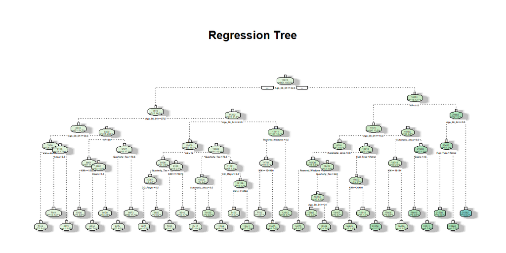

```r
# Plots a regression tree
fancyRpartPlot(RegressTree, caption = NULL, main = "Regression Tree", palettes = "GnBu", digits = -3)
```

After running the regression tree based on 15 car attributes, the model produces a tree with 34 terminal nodes and 861 observations at the root node. The first variable we split on optimizes a reduction in SSE (sum of squared errors). After reviewing the tree or the RegressTree output, it can be since that the first node is observations with Age_08_04 >= 32.5 with 743 used cars and an average price of $9,620.00. If one continues to follow the splits, the nodes will become smaller as they reach their terminal nodes. Additionally, we can see that the regression tree only utilized 10 variables out of the 15.

**Resources:**  
- https://uc-r.github.io/regression_trees  
- https://bookdown.org/mpfoley1973/data-sci/regression-tree.html

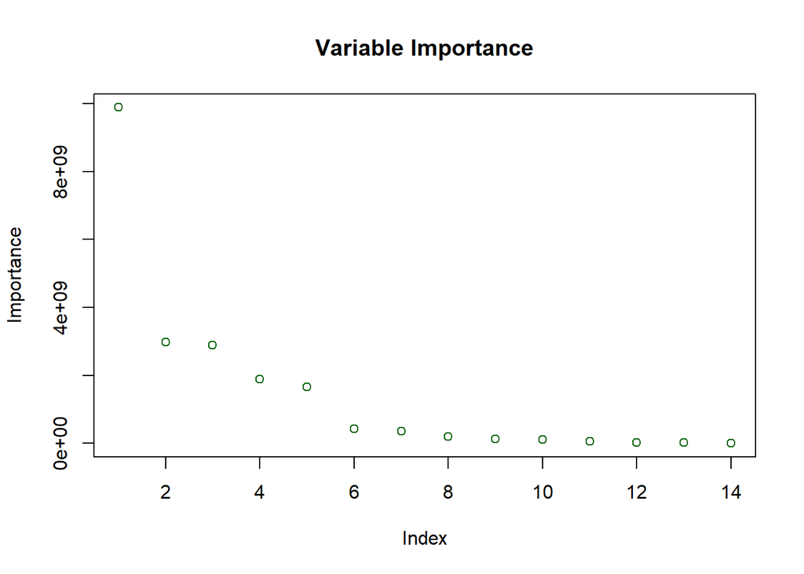

```r
# Calculates how much a given model "uses" that variable to make accurate predictions
importance <- t(t(RegressTree$variable.importance)) # Transpose the matrix to create a column with the variable labels to acquire the importance of each

# Visually see the variable importance within the tree
plot(importance, main = "Variable Importance", col = "darkgreen", ylab = "Importance")
```

```r
importance # Print the importance table
```

```
##                        [,1]
## Age_08_04        9885745349
## Automatic_airco  2987651311
## KM               2886703313
## Quarterly_Tax    1885088412
## HP               1665897142
## Guarantee_Period  430364046
## CD_Player         357332146
## Fuel_Type         206914123
## Airco             122474786
## Powered_Windows   109250988
## Doors              63966015
## Mfr_Guarantee      21300178
## Automatic          19776457
## Sport_Model         3395399
```

Out of the 15 car specifications, there are several variables that are important for predicting car price. In the plot above, Age_08_04 is the most influential and truly stands apart from all other car attributes. If we review the next three, they are Automatic_airco, KM, and Quarterly_Tax. Another way to see that these are the top four predictors is by looking at the SSE in the RegressTree output as the second value demonstrates the importance of the variable. Hence why the reader will see that Age_08_04 is first in both analyses.

**ii.** *Compare the prediction errors of the training and validation sets by examining their RMS error and by plotting the two box plots. What is happening with the training set predictions? How does the predictive performance of the validation set compare to the training set? Why does this occur?*

```r
# Prediction error for training set
Regress_preds_cart_T <- predict(RegressTree, train.df, type = "vector")
res_train <- train.df$Price - Regress_preds_cart_T

# Create the RMSE calculation
cs_rmse_T <- RMSE(
   pred = Regress_preds_cart_T,
   obs = train.df$Price)

# Prediction error for validation set
Regress_preds_cart_V <- predict(RegressTree, valid.df, type = "vector")
res_valid <- valid.df$Price - Regress_preds_cart_V

# Create the RMSE calculation
cs_rmse_V <- RMSE(
   pred = Regress_preds_cart_V,
   obs = valid.df$Price)
```

```r
cs_rmse_T # Print the training RMSE
```

```
## [1] 986.5121
```

```r
cs_rmse_V # Print the validation RMSE
```

```
## [1] 1192.877
```

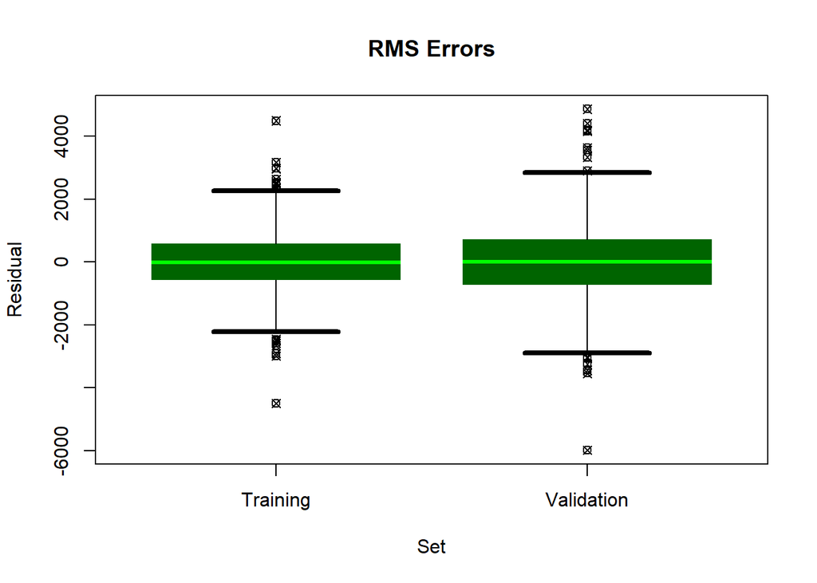

```r
# Create a data frame from the training and validation errors in order to plot
residual <-data.frame(residual = c(res_train, res_valid),
                 Set = c(rep("Training", length(res_train)), rep("Validation", length(res_valid))))

# Boxplot graph showing the difference between the training and validation sets
boxplot(residual ~ Set, data = residual, main = "RMS Errors", ylab = "Residual", col= "darkgreen", medcol = "green", boxlty = 0, border = "black", whisklty = 1, staplelwd = 4, outpch = 13, outcex = 1, outcol = "black")
```

‘The RMS error (RMSE) (root-mean-squared error) is more informative of the error magnitude: it takes the square root of the average squared error, so it gives an idea of the typical error (whether positive or negative) in the same scale as that used for the original outcome variable. As we might expect, the RMS error for the validation data which the model is seeing for the first time in making these predictions, is larger than for the training data, which were used in training the model.’ When comparing the two RMS errors scores (training at 987 and validation at 1193), the training set has a lower value, and thus, we expect it to predict the expected prices better. This is due to the validation using different observations than what the training utilized. Within the validation boxplot, more outliers are observed due to this explanation. As I stated before with the deeper tree with cp = 0, the RegressTree does not consider the full tree. So when we review the boxplots above, the training mean will not be 1.  
**Resources:**  
- Pages 41 to 42  
- https://bookdown.org/mpfoley1973/data-sci/regression-tree.html

**iv.** *Prune the full tree using the cross-validation error. Compared to the full tree, what is the predictive performance for the validation set?*  
As we continuously discuss the problem of overfitting, I wanted to demonstrate the dangers of how this could lead to poor performance on the test data if a deep tree were used. The issue is that the terminal nodes will be based on a very small number of records. According the the book (page 221), ‘the class difference is likely to be attributed to noise rather than predictor information.’ Although the tree below looks pretty neat, we want to prune and correctly fit our model for a specific number of splits. Although the analysis is not included due to the length, the output for ‘Deeper.CT’ shows the bottom values and how they represent the terminal nodes that are seen with values such as 0. We can visually see the difference of how the trees are built. The RegressTree has 34 terminal nodes while the Deeper.CT has 698.

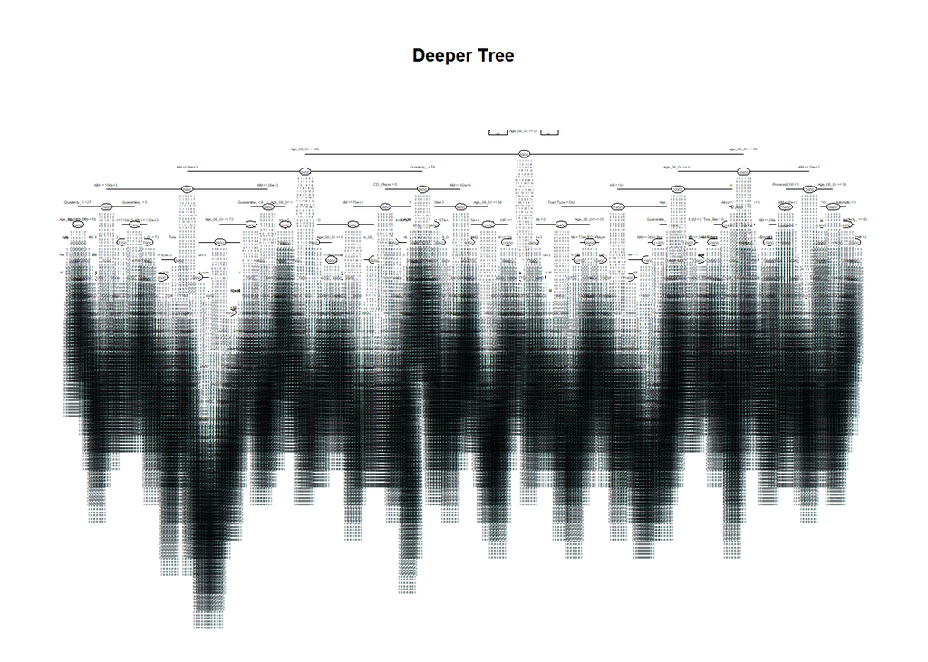

```r
# Create deep tree (page 219)
Deeper.CT <- rpart(formula = Price ~ Age_08_04 + KM + Fuel_Type + HP + Automatic + Doors +
              Quarterly_Tax + Mfr_Guarantee + Guarantee_Period + Airco +
              Automatic_airco + CD_Player + Powered_Windows + Sport_Model + Tow_Bar,
            data = train.df, method = "class", cp = 0, minsplit = 1)

# Plot tree
prp(Deeper.CT, type = 1, extra = 1, under = TRUE, split.font = 1, varlen = -10, main = "Deeper Tree", box.col=ifelse(Deeper.CT$frame$var == "<leaf>", 'gray', 'white'))
```

```r
# Count number of leaves (page 221)
length(Deeper.CT$frame$var[Deeper.CT$frame$var == "<leaf>"])
```

```
## [1] 698
```

To avoid overfitting, we use a technique called ‘pruning.’ This method allows the analyst to cut the tree to dismiss the weakest branches that do not really reduce the error rate. Therefore, these should be removed. It will be seen that from the RegressTree to the PrunedTree, we have re-designated a decision node as a terminal node.

```r
#printcp(RegressTree) # Display the cp results
#plotcp(RegressTree) # Cross Validation error

# Create a table showing the various attributes to determine the best cp to prune the regression tree
RegressTree$cptable %>%
   data.frame() %>%
   mutate(min_xerror_idx = which.min(RegressTree$cptable[, "xerror"]), rownum = row_number(), xerror_cap = RegressTree$cptable[min_xerror_idx, "xerror"] + RegressTree$cptable[min_xerror_idx, "xstd"], eval = case_when(rownum == min_xerror_idx ~ "Min Xerror", xerror < xerror_cap ~ "Under Cap", TRUE ~ "")) %>% select(-rownum, -min_xerror_idx)
```

```
##             CP nsplit  rel.error    xerror       xstd xerror_cap       eval
## 1  0.647758496      0 1.00000000 1.0037275 0.08617164  0.1329735
## 2  0.100475226      1 0.35224150 0.3553730 0.03033166  0.1329735
## 3  0.047248206      2 0.25176628 0.2612925 0.02956409  0.1329735
## 4  0.021601383      3 0.20451807 0.2444506 0.02678026  0.1329735
## 5  0.018414061      4 0.18291669 0.2002820 0.01686528  0.1329735
## 6  0.015090665      5 0.16450263 0.1912711 0.01662110  0.1329735
## 7  0.013539795      6 0.14941196 0.1824319 0.01617789  0.1329735
## 8  0.010905395      7 0.13587217 0.1629154 0.01468948  0.1329735
## 9  0.005466303      8 0.12496677 0.1488066 0.01359104  0.1329735
## 10 0.004844946      9 0.11950047 0.1401366 0.01195843  0.1329735
## 11 0.004193267     10 0.11465552 0.1383719 0.01191044  0.1329735
## 12 0.003655782     11 0.11046226 0.1361991 0.01186621  0.1329735
## 13 0.003246217     12 0.10680647 0.1315351 0.01134764  0.1329735  Under Cap
## 14 0.002991839     13 0.10356026 0.1308300 0.01145629  0.1329735  Under Cap
```

[output cut: 18 more lines]

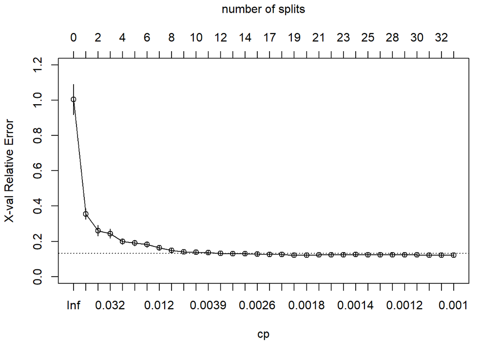

```r
plotcp(RegressTree, upper = "splits") # Provides a graphical representation to the cross validated error summary
```

```r
# Build a second regression tree
RegressTree2 <- rpart(formula = Price ~ Age_08_04 + KM + Fuel_Type + HP + Automatic + Doors +
              Quarterly_Tax + Mfr_Guarantee + Guarantee_Period + Airco +
              Automatic_airco + CD_Player + Powered_Windows + Sport_Model + Tow_Bar,
            data = train.df, method = "anova",
            control = rpart.control(minbucket = 1, maxdepth = 30, cp = 0)) # Set cp = 0 to obtain the full tree

# Prune by lower cp 0.003655782 based on plotcp(RegressTree,...)
Pruned_tree <- prune(RegressTree2, cp= 0.003655782)

Pruned_tree # Print the Pruned_Tree
```

```
## n= 861
##
## node), split, n, deviance, yval
##       * denotes terminal node
##
##  1) root 861 11995140000 10812.970
##    2) Age_08_04>=32.5 743  2900685000  9615.801
##      4) Age_08_04>=57.5 471   813509300  8647.943
##        8) Age_08_04>=68.5 226   257064600  7875.686 *
##        9) Age_08_04< 68.5 245   297333200  9360.310
##         18) HP< 88 97   133055100  8800.629 *
##         19) HP>=88 148   113979300  9727.128 *
##      5) Age_08_04< 57.5 272   881961300 11291.760
##       10) Age_08_04>=43.5 165   495026100 10566.080
##         20) HP< 79 24   104184500  8407.917
##           40) Quarterly_Tax< 124.5 6    26048330  6066.667 *
##           41) Quarterly_Tax>=124.5 18    34284600  9188.333 *
##         21) HP>=79 141   260029900 10933.430 *
##       11) Age_08_04< 43.5 107   166056000 12410.790 *
##    3) Age_08_04< 32.5 118  1324500000 18351.050
##      6) HP< 113 106   551961200 17613.670
##       12) Age_08_04>=16.5 73   246701900 16781.420
##         24) Automatic_airco< 0.5 48   112502500 16137.500 *
##         25) Automatic_airco>=0.5 25    76083640 18017.760 *
##       13) Age_08_04< 16.5 33   142847500 19454.700
##         26) Automatic_airco< 0.5 20    33102010 18318.250 *
##         27) Automatic_airco>=0.5 13    44176480 21203.080 *
##      7) HP>=113 12   205790600 24864.580
##       14) Age_08_04>=5.5 9    23500560 22622.220 *
##       15) Age_08_04< 5.5 3     1275417 31591.670 *
```

```r
printcp(Pruned_tree) # Display the cp results
```

```
##
## Regression tree:
## rpart(formula = Price ~ Age_08_04 + KM + Fuel_Type + HP + Automatic +
##     Doors + Quarterly_Tax + Mfr_Guarantee + Guarantee_Period +
##     Airco + Automatic_airco + CD_Player + Powered_Windows + Sport_Model +
##     Tow_Bar, data = train.df, method = "anova", control = rpart.control(minbucket = 1,
##     maxdepth = 30, cp = 0))
##
## Variables actually used in tree construction:
## [1] Age_08_04       Automatic_airco HP              Quarterly_Tax
##
## Root node error: 1.1995e+10/861 = 13931635
##
## n= 861
##
##           CP nsplit rel error  xerror     xstd
## 1  0.6477585      0   1.00000 1.00288 0.085932
## 2  0.1004752      1   0.35224 0.35509 0.030000
## 3  0.0472482      2   0.25177 0.25823 0.029182
## 4  0.0216014      3   0.20452 0.22047 0.016498
## 5  0.0184141      4   0.18292 0.19793 0.016423
## 6  0.0150907      5   0.16450 0.19473 0.016149
## 7  0.0135398      6   0.14941 0.19071 0.015641
## 8  0.0109054      7   0.13587 0.16773 0.014290
## 9  0.0054663      8   0.12497 0.14446 0.011716
## 10 0.0048449      9   0.11950 0.14650 0.012593
## 11 0.0041933     10   0.11466 0.13942 0.012335
## 12 0.0036558     11   0.11046 0.13572 0.012056
## 13 0.0036558     12   0.10681 0.13499 0.011997
```

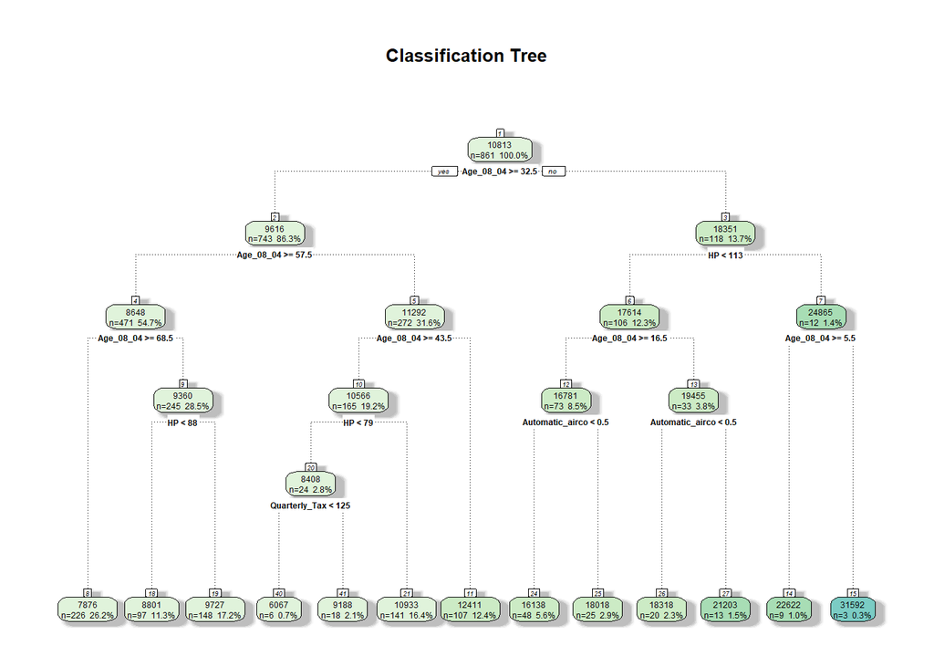

```r
# Plots a regression tree
fancyRpartPlot(Pruned_tree, caption = NULL, main = "Classification Tree", palettes = "GnBu", digits = -3)
```

```r
# Calculates how much a given model "uses" that variable to make accurate predictions
importance <- t(t(Pruned_tree$variable.importance)) # Transpose the matrix to create a column with the variable labels to acquire the importance of each
importance # Print the importance table
```

```
##                        [,1]
## Age_08_04        9822893732
## Automatic_airco  2955108141
## KM               2715668253
## Quarterly_Tax    1755963860
## HP               1630450193
## Guarantee_Period  419690154
## CD_Player         316358282
## Fuel_Type         141688844
## Airco              51645297
## Powered_Windows    37279606
## Automatic          14342301
## Mfr_Guarantee      12611624
```

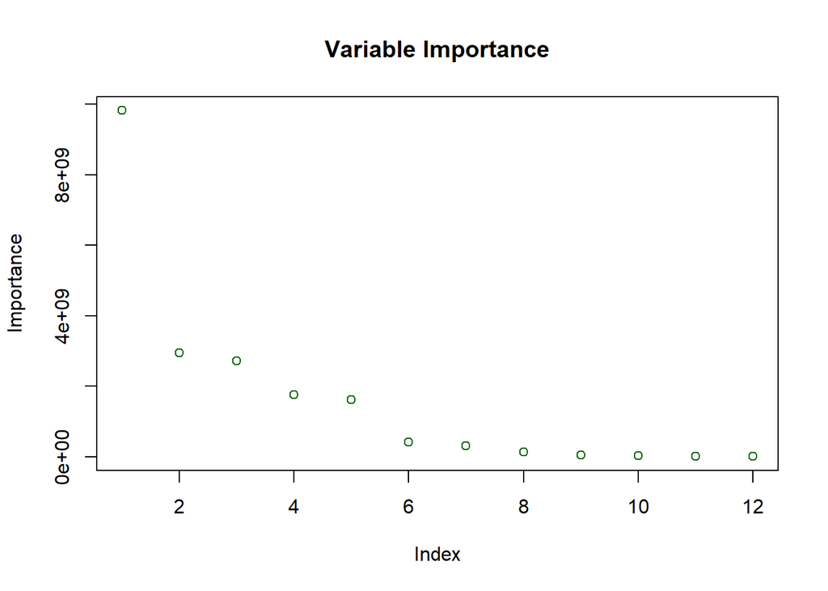

```r
# Visually see the variable importance within the treee
plot(importance, main = "Variable Importance", col = "darkgreen", ylab = "Importance")
```

The top four most influential variables continue to be Age_08_04, Automatic_airco, KM, and Quarterly_Tax.

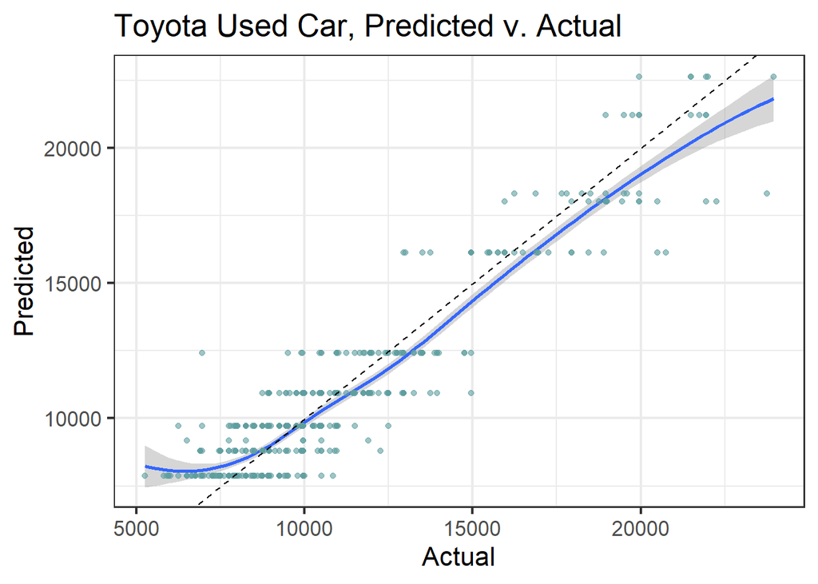

```r
# Prediction error for training set
Prune_preds_cart_T <- predict(Pruned_tree, train.df, type = "vector")

# Calculate the RMSE for training
cs_rmse_cart_T <- RMSE(
   pred = Prune_preds_cart_T,
   obs = train.df$Price)

# Prediction error for validation set
Prune_preds_cart_V <- predict(Pruned_tree, valid.df, type = "vector")

# Calculate the RMSE for validation
cs_rmse_cart_V <- RMSE(
   pred = Prune_preds_cart_V,
   obs = valid.df$Price)

# Create a new data frame to plot Predicted and Actual values to visualize the differences
data.frame(Predicted = Prune_preds_cart_V, Actual = valid.df$Price) %>%
   ggplot(aes(x = Actual, y = Predicted)) +
   geom_smooth() +
   geom_point(alpha = 0.6, color = "cadetblue") +
   geom_abline(intercept = 0, slope = 1, linetype = 2) +
   labs(title = "Toyota Used Car, Predicted v. Actual")
```

```r
# Printing out the various outputs for RSME
cat(paste("Regression Training RMSE: ",round(cs_rmse_T, 2)),paste("Regression Validation RMSE: ",round(cs_rmse_V, 2)),paste("Pruned Training RMSE:",round(cs_rmse_cart_T,2)),
paste("Pruned Validation RMSE: ",round(cs_rmse_cart_V,2)),
sep='\n')
```

```
## Regression Training RMSE:  986.51
## Regression Validation RMSE:  1192.88
## Pruned Training RMSE: 1219.83
## Pruned Validation RMSE:  1246.53
```

**Resource:** https://statinfer.com/203-3-10-pruning-a-decision-tree-in-r/

**B.** *Let us see the effect of turning the price variable into a categorical variable. First, create a new variable that categorizes price into 20 bins. Now re-partition the data keeping Binned_Price instead of Price. Run a classification tree with the same set of input variables as in the RT, and with Binned_Price as the output variable. Keep the minimum number of records in a terminal node to 1.*

**i.** *Compare the tree generated by the CT with the one generated by the RT. Are they different? (Look at structure, the top predictors, size of tree, etc.) Why?*

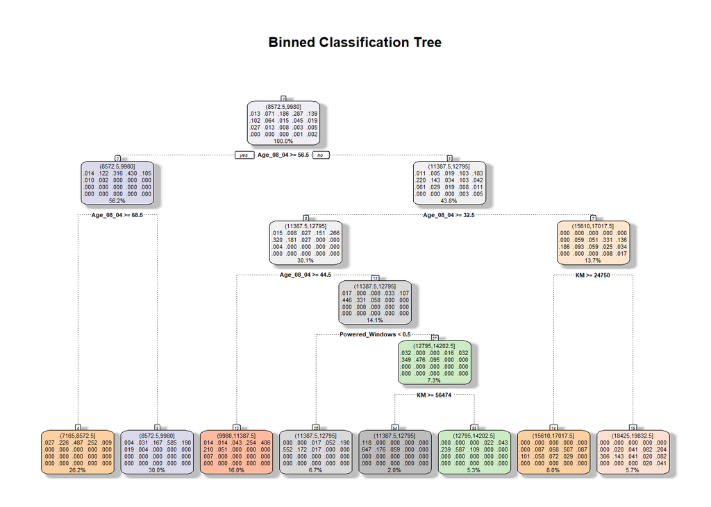

```r
# Categorize Price into 20 bins
Binned_Price <- cut(Toyota$Price, breaks = 20, dig.lab = 10) # Came from stackover

# Add Binned_Price to Toyota
Toyota <- cbind(Toyota, Binned_Price)

# Split data into training and validation datasets
train <- Toyota[train.index, ]
valid <- Toyota[valid.index, ]

# Run classification tree
ClassTree <- rpart(Binned_Price ~ Age_08_04 + KM + Fuel_Type + HP + Automatic + Doors +
              Quarterly_Tax + Mfr_Guarantee + Guarantee_Period + Airco +
              Automatic_airco + CD_Player + Powered_Windows + Sport_Model + Tow_Bar,
            data = train, method = "class", control = rpart.control(minbucket = 1))

# Plots a regression tree
fancyRpartPlot(ClassTree, caption = NULL, main = "Binned Classification Tree", palettes = "GnBu", digits = -3)  # Digits is used to remove scientific notation
```

```r
printcp(ClassTree) # Print cp
```

```
##
## Classification tree:
## rpart(formula = Binned_Price ~ Age_08_04 + KM + Fuel_Type + HP +
##     Automatic + Doors + Quarterly_Tax + Mfr_Guarantee + Guarantee_Period +
##     Airco + Automatic_airco + CD_Player + Powered_Windows + Sport_Model +
##     Tow_Bar, data = train, method = "class", control = rpart.control(minbucket = 1))
##
## Variables actually used in tree construction:
## [1] Age_08_04       KM              Powered_Windows
##
## Root node error: 614/861 = 0.71312
##
## n= 861
##
##         CP nsplit rel error  xerror     xstd
## 1 0.078990      0   1.00000 1.00000 0.021615
## 2 0.063518      2   0.84202 0.84691 0.023373
## 3 0.043974      3   0.77850 0.78827 0.023710
## 4 0.017915      4   0.73453 0.74104 0.023856
## 5 0.013029      5   0.71661 0.74104 0.023856
## 6 0.010000      7   0.69055 0.74104 0.023856
```

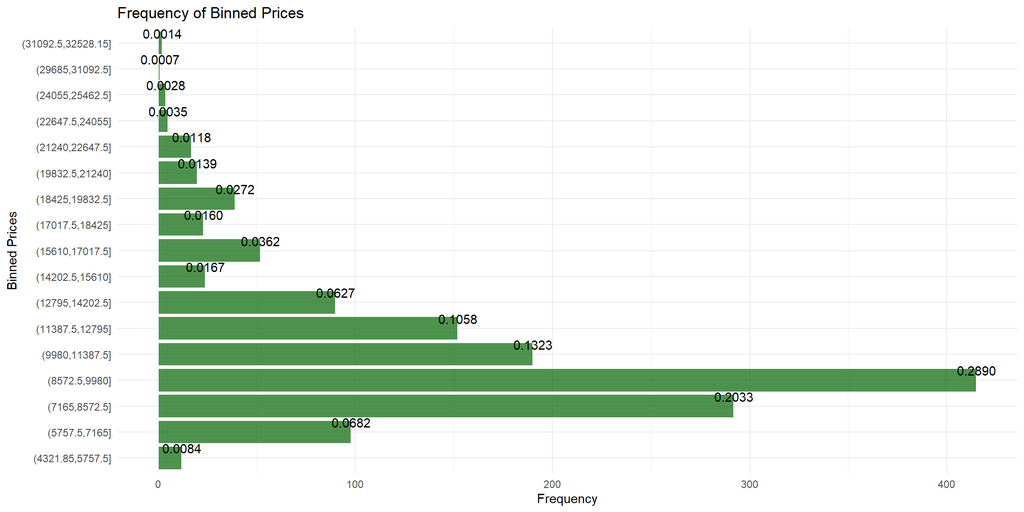

```r
# Create historgram from resource below
ggplot(data = as_tibble(Binned_Price), mapping = aes(x=value)) +
  geom_bar(fill="darkgreen",color="white",alpha=0.7) +
  stat_count(geom="text", aes(label=sprintf("%.4f",..count../length(Binned_Price))), vjust=-0.5) +
  labs(x='Binned Prices') +
  labs(y='Frequency') +
  coord_flip() +
  ggtitle("Frequency of Binned Prices") +
  theme_minimal()
```

```r
# Calculates how much a given model "uses" that variable to make accurate predictions
importance <- t(t(ClassTree$variable.importance)) # Transpose the matrix to create a column with the variable labels to acquire the importance of each
importance # Print the importance table
```

```
##                         [,1]
## Age_08_04        152.5600337
## KM                58.4034964
## CD_Player         26.9950441
## Automatic_airco   19.8587797
## Sport_Model       18.6676759
## Airco             18.2834578
## Quarterly_Tax     16.1438410
## HP                 7.2273021
## Powered_Windows    7.0148174
## Mfr_Guarantee      2.9656114
## Doors              2.6224520
## Fuel_Type          1.0327227
## Automatic          0.4534818
## Guarantee_Period   0.4534818
```

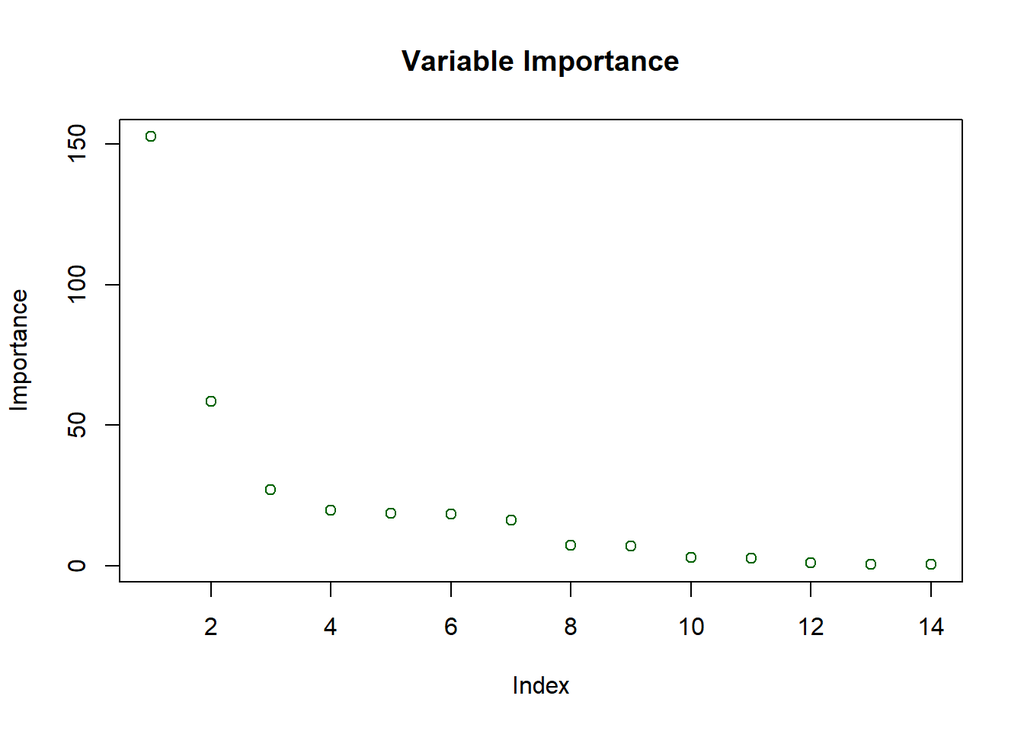

```r
# Visually see the variable importance within the tree
plot(importance, main = "Variable Importance", col = "darkgreen", ylab = "Importance")
```

‘There are two fundamental differences between the classification and regression trees. The classification tree splits the response variable into mainly two classes ’Yes’ or ‘No’, also can be numerically categorized as 1 or 0. The regression trees are leveraged in case where the response variable is either continuous or numeric, but not categorical.’ In this problem, we use the regression tree in the case of used car prices. Therefore, the reader will notice that there are various differences between the two models. For starters, we are comparing price as a continuous variable while the classification treats it as a categorical value. This will change the layout of the overall trees as the RT is more complex and larger than the CT which has only eight terminal nodes compared to 34. Additionally, if we review the top predictors, even though both models consider ‘Age_04_08’ as the first, KM changes positions in the RT from three to two in the CT. The third predictor for CT is ‘CD_Player’ and the second most important variable for the regression tree is ‘Automatic_airco’. It is also noticed that the two models use different variables. For instance, the regression tree uses 10 while CT only considers Age_08_04, KM, and Powered_Windows. The bar chart is useful to analyze how the prices are binned and the count of which used cars are within each. The biggest bin at over 400 observations is ($8,572.5 to $9,980].

**Resources:**:  
- https://medium.com/@gp_pulipaka/an-essential-guide-to-classification-and-regression-trees-in-r-language-4ced657d176b  
- https://stackoverflow.com/questions/70814726/cut-function-puts-all-data-in-a-single-interval

**ii.** *Predict the price, using the RT and the CT, of a used Toyota Corolla with the specifications listed in the below table.*

```r
# Created the new car record
new_car <- data.frame(Age_08_04 = 77, KM = 117000, Fuel_Type = "Petrol", HP = 110, Automatic = 0, Doors = 5, Quarterly_Tax = 100, Mfr_Guarantee = 0, Guarantee_Period = 3, Airco = 1, Automatic_airco = 0, CD_Player = 0, Powered_Windows = 0, Sport_Model = 0, Tow_Bar = 1)

# Prediction with Regression
price.newcar_RT <- predict(RegressTree, newdata = new_car)
price.newcar_RT # Print the price of regression
```

```
##        1
## 7318.056
```

```r
# Prediction with Classification
price.newcar_CT <- predict(ClassTree, newdata = new_car, type = "class")
price.newcar_CT # Print the price of classification
```

```
##             1
## (7165,8572.5]
## 20 Levels: (4321.85,5757.5] (5757.5,7165] (7165,8572.5] ... (31092.5,32528.15]
```

When predicting the new used car’s price, we obtain a value of $7,318 from the regression tree and a range of ($7,165 to $8,572.5] for the classification tree. The one disadvantage of the range value is that it approximates and doesn’t give a definite value but what it would be if it were binned. We can see that the RT value falls within the CT range.

**iii.** *Compare the predictions in terms of the predictors that were used, the magnitude of the difference between the two predictions, and the advantages and disadvantages of the two methods.*

**Regression Tree Top Predictors**

| Variable | Importance Level |
| --- | --- |
| Age_08_04 | 9885745349 |
| Automatic_airco | 2987651311 |
| KM | 2886703313 |
| Quarterly_Tax | 1885088412 |

**Classification Tree Top Predictors**

| Variable | Importance Level |
| --- | --- |
| Age_08_04 | 152.560 |
| KM | 58.403 |
| CD_Player | 26.995 |
| Automatic_airco | 19.859 |

**Regression Tree’s variables actually used in tree construction:**  
- Age_08_04  
- Airco  
- Automatic_airco  
- CD_Player  
- Doors  
- Fuel_Type  
- HP  
- KM  
- Powered_Windows  
- Quarterly_Tax

**Classification Tree’s variables actually used in tree construction:**  
- Age_08_04  
- KM  
- Powered_Windows

Overall, the classification tree is less complex as it uses only three variables compared to the regression using ten. Per the information above, the top four most influential variables in each model include three of the four in each. Their magnitudes are similar in the fact that ‘Age_04_08’ dominates how important that car specification is while the other three are much lower. In terms of the CT, we bin a continuous variable into 20 ranges which might not produce optimal splits. Fortunately for both models, they compliment each other in the fact that we can use them to compare price results for a new car. Below, I will summarize the disadvantages and advantages of both models:

Please note that some of these advantages and disadvantges can be for both trees.  
**Regression Tree** - Can become very complex with a multitude of terminal nodes  
- Tree structure can be quite unstable, shifting substantially depending on the sample chosen  
- A fully-fit tree will invariably lead to overfitting  
+ Predicts one value for exact price in terms of a new record

**Classification Tree** - Uses a price range for a new car which is not approximate, loses efficiency  
- A small change in the data can cause a large change in the structure of the decision tree causing instability  
+ Focuses on less variables  
+ Due to its simplicity, it is easy to visualize, interpret, and manipulate  
+ Follows a non-parametric method

**Resource:** https://pythonprogramminglanguage.com/what-are-the-advantages-of-using-a-decision-tree-for-classification/#:~:text=Advantages%20of%20Using%20a%20Decision%20Tree%20for%20Classification&text=Due%20to%20its%20simplicty%2C%20anyone,easy%20to%20learn%20and%20understand.